# Prosper Loan Data Exploration

## by Cibele Yamanaka

This document explores a dataset containing 49738 loans and 81 columns such as amount, borrower rate (or interest rate), current loan status, borrower income, and many others.

```python
# import all packages and set plots to be embedded inline
import numpy as np
import pandas as pd
import matplotlib.pyplot as plt
import seaborn as sb

%matplotlib inline
```

```python
# load in the dataset into a pandas dataframe, print statistics
loan = pd.read_csv('prosperLoanData.csv')
```

```python
# high-level overview of data shape and composition
print(loan.shape)
print(loan.dtypes)
print(loan.head(10))
```

```
(49738, 81)
ListingKey                              object
ListingNumber                            int64
ListingCreationDate                     object
CreditGrade                             object
Term                                     int64
LoanStatus                              object
ClosedDate                              object
BorrowerAPR                            float64
BorrowerRate                           float64
LenderYield                            float64
EstimatedEffectiveYield                float64
EstimatedLoss                          float64
EstimatedReturn                        float64
ProsperRating (numeric)                float64
ProsperRating (Alpha)                   object
ProsperScore                           float64
ListingCategory (numeric)                int64
BorrowerState                           object
Occupation                              object
EmploymentStatus                        object
EmploymentStatusDuration               float64
IsBorrowerHomeowner                       bool
CurrentlyInGroup                          bool
GroupKey                                object
DateCreditPulled                        object
CreditScoreRangeLower                  float64
CreditScoreRangeUpper                  float64
FirstRecordedCreditLine                 object
CurrentCreditLines                     float64
OpenCreditLines                        float64
                                        ...
TotalProsperLoans                      float64
TotalProsperPaymentsBilled             float64
OnTimeProsperPayments                  float64
ProsperPaymentsLessThanOneMonthLate    float64
ProsperPaymentsOneMonthPlusLate        float64
ProsperPrincipalBorrowed               float64
ProsperPrincipalOutstanding            float64
ScorexChangeAtTimeOfListing            float64
```

[output cut: 81 more lines]

```
9            1.0              0.0                        0.0

  InvestmentFromFriendsAmount Investors
0                         0.0     258.0
1                         0.0       1.0
2                         0.0      41.0
3                         0.0     158.0
4                         0.0      20.0
5                         0.0       1.0
6                         0.0       1.0
7                         0.0       1.0
8                         0.0       1.0
9                         0.0       1.0

[10 rows x 81 columns]
```

```python
# Subset the dataframe by selecting features of interest
cols = ['LoanOriginalAmount', 'BorrowerAPR', 'BorrowerRate', 'StatedMonthlyIncome', 'Term', 'ProsperRating (Alpha)',
        'EmploymentStatus', 'BorrowerState']
loan_new = loan[cols]
```

```python
# descriptive statistics for numeric variables
loan_new.describe()
```

|  | LoanOriginalAmount | BorrowerAPR | BorrowerRate | StatedMonthlyIncome | Term |
| --- | --- | --- | --- | --- | --- |
| count | 49737.000000 | 49731.000000 | 49738.000000 | 49738.000000 | 49738.000000 |
| mean | 8346.368498 | 0.218525 | 0.192519 | 5582.380092 | 40.871607 |
| std | 6256.962272 | 0.080494 | 0.074951 | 5111.355523 | 10.441771 |
| min | 1000.000000 | 0.013150 | 0.000000 | 0.000000 | 12.000000 |
| 25% | 4000.000000 | 0.156290 | 0.133400 | 3208.333333 | 36.000000 |
| 50% | 6500.000000 | 0.208690 | 0.183000 | 4666.666667 | 36.000000 |
| 75% | 12000.000000 | 0.283700 | 0.250000 | 6790.750000 | 36.000000 |
| max | 35000.000000 | 0.512290 | 0.497500 | 483333.333333 | 60.000000 |

```python
loan_new.corr()
```

|  | LoanOriginalAmount | BorrowerAPR | BorrowerRate | StatedMonthlyIncome | Term |
| --- | --- | --- | --- | --- | --- |
| LoanOriginalAmount | 1.000000 | -0.317720 | -0.323386 | 0.293992 | 0.341014 |
| BorrowerAPR | -0.317720 | 1.000000 | 0.990004 | -0.119995 | -0.008485 |
| BorrowerRate | -0.323386 | 0.990004 | 1.000000 | -0.128965 | 0.021827 |
| StatedMonthlyIncome | 0.293992 | -0.119995 | -0.128965 | 1.000000 | 0.047876 |
| Term | 0.341014 | -0.008485 | 0.021827 | 0.047876 | 1.000000 |

```python
loan_new.sample(50)
```

|  | LoanOriginalAmount | BorrowerAPR | BorrowerRate | StatedMonthlyIncome | Term | ProsperRating (Alpha) | EmploymentStatus | BorrowerState |
| --- | --- | --- | --- | --- | --- | --- | --- | --- |
| 9290 | 15000.0 | 0.25781 | 0.2199 | 10416.666667 | 36 | D | Employed | MI |
| 16048 | 4000.0 | 0.29537 | 0.2566 | 3333.333333 | 36 | D | Employed | OH |
| 25246 | 10582.0 | 0.16289 | 0.1490 | 5675.000000 | 60 | A | Employed | LA |
| 12875 | 10000.0 | 0.18913 | 0.1655 | 2833.333333 | 60 | C | Employed | NC |
| 7739 | 2500.0 | 0.29776 | 0.2900 | 1400.000000 | 36 | NaN | Not available | NaN |
| 5970 | 8750.0 | 0.17618 | 0.1700 | 1724.583333 | 36 | NaN | Full-time | AZ |
| 43201 | 20000.0 | 0.29776 | 0.2900 | 15583.333333 | 36 | NaN | Not available | NaN |
| 31916 | 7000.0 | 0.11296 | 0.0920 | 5000.000000 | 36 | A | Full-time | CA |
| 48174 | 7000.0 | 0.15040 | 0.1274 | 5833.333333 | 60 | B | Employed | IL |
| 46905 | 3000.0 | 0.13871 | 0.1210 | 1200.000000 | 36 | NaN | Full-time | IL |
| 19974 | 2000.0 | 0.10867 | 0.1000 | 2500.000000 | 36 | NaN | Full-time | NY |
| 7769 | 25000.0 | 0.14709 | 0.1400 | 3516.916667 | 36 | NaN | Full-time | OH |
| 26078 | 20000.0 | 0.08191 | 0.0785 | 13866.666667 | 36 | AA | Full-time | NJ |
| 29921 | 25000.0 | 0.21392 | 0.1897 | 5416.666667 | 60 | B | Employed | NC |
| 34162 | 16000.0 | 0.12427 | 0.0964 | 11666.666667 | 36 | A | Employed | FL |
| 30763 | 10000.0 | 0.17754 | 0.1414 | 6250.000000 | 36 | B | Employed | IN |
| 24295 | 15000.0 | 0.07111 | 0.0669 | 8083.333333 | 60 | AA | Employed | CA |
| 16973 | 7500.0 | 0.29510 | 0.2599 | 2416.666667 | 36 | D | Employed | WA |
| 30149 | 11500.0 | 0.14453 | 0.1219 | 5833.333333 | 60 | A | Employed | TX |
| 22909 | 15000.0 | 0.21474 | 0.1905 | 4166.666667 | 60 | C | Employed | IL |
| 34374 | 15000.0 | 0.27285 | 0.2346 | 10416.666667 | 36 | D | Employed | CA |
| 33701 | 10000.0 | 0.24282 | 0.2179 | 6250.000000 | 60 | C | Self-employed | NY |
| 38039 | 3500.0 | 0.13972 | 0.0820 | 3333.333333 | 12 | A | Employed | KY |
| 48592 | 7000.0 | 0.20462 | 0.1679 | 3333.333333 | 36 | B | Employed | FL |
| 979 | 11500.0 | 0.24302 | 0.2181 | 4583.333333 | 60 | C | Employed | NC |
| 34502 | 6000.0 | 0.11766 | 0.0899 | 4333.333333 | 36 | A | Full-time | VA |
| 25816 | 10000.0 | 0.28362 | 0.2574 | 3660.916667 | 60 | E | Employed | CA |
| 45041 | 16500.0 | 0.13227 | 0.1099 | 7500.000000 | 60 | A | Employed | NC |
| 7644 | 4000.0 | 0.12081 | 0.0930 | 2500.000000 | 36 | A | Self-employed | PA |
| 20649 | 10000.0 | 0.22908 | 0.2045 | 3083.333333 | 60 | C | Employed | MA |
| 23967 | 9000.0 | 0.09000 | 0.0766 | 6666.666667 | 36 | AA | Employed | PA |
| 15745 | 25000.0 | 0.13202 | 0.1250 | 11666.666667 | 36 | NaN | Not available | CA |
| 14572 | 10600.0 | 0.12992 | 0.1076 | 8000.000000 | 60 | AA | Employed | NC |
| 33179 | 19000.0 | 0.16056 | 0.1390 | 6750.000000 | 36 | A | Employed | TX |
| 13989 | 7500.0 | 0.12188 | 0.1149 | 3917.333333 | 36 | NaN | Full-time | NaN |
| 17334 | 4000.0 | 0.32538 | 0.2859 | 3708.333333 | 36 | E | Employed | MS |
| 47345 | 10000.0 | 0.27467 | 0.2399 | 9000.000000 | 36 | D | Employed | FL |
| 27926 | 4000.0 | 0.25781 | 0.2199 | 4641.666667 | 36 | D | Employed | TX |
| 49647 | 20000.0 | 0.18197 | 0.1585 | 5958.333333 | 60 | C | Employed | NM |
| 28368 | 3600.0 | 0.25757 | 0.2500 | 1666.666667 | 36 | NaN | Full-time | AL |
| 9000 | 8000.0 | 0.16717 | 0.1600 | 4000.000000 | 36 | NaN | Not available | NaN |
| 35328 | 3000.0 | 0.29173 | 0.2840 | 3833.333333 | 36 | NaN | Not available | MO |
| 27814 | 5000.0 | 0.09688 | 0.0900 | 2000.000000 | 36 | NaN | Full-time | IL |
| 27437 | 5500.0 | 0.20451 | 0.1945 | 4876.583333 | 36 | NaN | Full-time | MO |
| 16102 | 4000.0 | 0.32446 | 0.2850 | 10416.666667 | 36 | E | Other | NY |
| 12726 | 25000.0 | 0.17090 | 0.1349 | 14583.333333 | 36 | B | Employed | IL |
| 43982 | 10000.0 | 0.18161 | 0.1671 | 1094.166667 | 36 | NaN | Self-employed | AR |
| 11919 | 2550.0 | 0.25757 | 0.2500 | 4166.666667 | 36 | NaN | Not available | CA |
| 22219 | 25000.0 | 0.21699 | 0.1800 | 9533.333333 | 36 | C | Employed | FL |
| 36588 | 10000.0 | 0.19501 | 0.1585 | 3333.333333 | 36 | C | Employed | CA |

### What is/are the main feature(s) of interest in your dataset?

I'm keen on figuring out which features are best for predicting the borrower's Annual Percentage Rate (APR) for the loan.

### What features in the dataset do you think will help support your investigation into your feature(s) of interest?

I expect that the total loan amount will have the strongest opposite effect on the APR of the loan: the higher the amount loan, the lower the APR. I also think that the borrowers stated monthly income, loan term, Prosper rating, employment status will also have effects on the APR.

## Univariate Exploration

I'll start by looking at the distribution of the main variable of interest: Borrower APR.

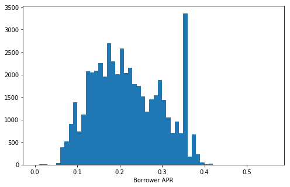

```python
# start with a standard-scaled plot
bins = np.arange(0, loan_new.BorrowerAPR.max()+0.05, 0.01)

plt.figure(figsize=[8, 5])
plt.hist(data = loan_new, x = 'BorrowerAPR', bins = bins);
plt.xlabel('Borrower APR');
plt.show()
```

The distribution of Borrower APR looks simmetrical between 0 and 0.4 centered at 0.2. The biggest peak between 0.35 and 0.36. Only very few loans have APR greater than 0.43.

```python
# Check loans with APR greater than 0.43
loan_new[loan_new.BorrowerAPR>0.43]
```

|  | LoanOriginalAmount | BorrowerAPR | BorrowerRate | StatedMonthlyIncome | Term | ProsperRating (Alpha) | EmploymentStatus | BorrowerState |
| --- | --- | --- | --- | --- | --- | --- | --- | --- |
| 18326 | 3000.0 | 0.45857 | 0.4500 | 10000.000000 | 36 | NaN | NaN | NaN |
| 22195 | 1789.0 | 0.46201 | 0.4500 | 2916.666667 | 36 | NaN | NaN | NaN |
| 36018 | 1500.0 | 0.51229 | 0.4975 | 2838.000000 | 36 | NaN | NaN | NaN |

The 3 borrowers with largest APR have small loan amount and don't have records of Prosper rating and employment status.

Next up, look at the distribution of the first predictor variable of interest: LoanOriginalAmount

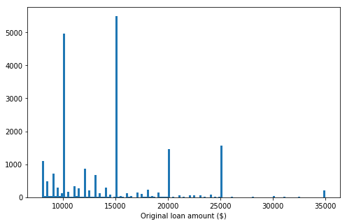

```python
# Checking the distribuition using LoanOriginalAmount Variable
bins = np.arange(8000, loan_new.LoanOriginalAmount.max()+200, 200)
plt.figure(figsize=[8, 5])
plt.hist(data = loan_new, x = 'LoanOriginalAmount', bins = bins);
plt.xlabel('Original loan amount ($)');
```

Now, look at the distributions of other variables of interest: stated monthly income.

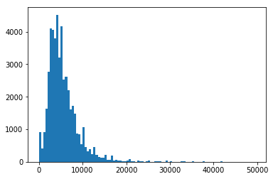

```python
# investigating further stated monthly income variable
bins_smi = np.arange(0, 50000, 500)
plt.hist(data = loan_new, x = 'StatedMonthlyIncome', bins=bins_smi);
```

The distribution of stated monthly income is visually right skewed, with most of stated monthly income less than 30k.

```python
# Checking borrowers with stated monthly income greater than 1e5
loan_new[loan_new.StatedMonthlyIncome>1e5]
```

|  | LoanOriginalAmount | BorrowerAPR | BorrowerRate | StatedMonthlyIncome | Term | ProsperRating (Alpha) | EmploymentStatus | BorrowerState |
| --- | --- | --- | --- | --- | --- | --- | --- | --- |
| 8066 | 2000.0 | 0.35643 | 0.3199 | 416666.666667 | 36 | HR | Employed | IL |
| 8870 | 12500.0 | 0.12700 | 0.1200 | 208333.333333 | 36 | NaN | Not available | CT |
| 17411 | 7500.0 | 0.35643 | 0.3199 | 483333.333333 | 36 | E | Employed | HI |
| 35218 | 1000.0 | 0.07389 | 0.0705 | 108333.333333 | 36 | AA | Full-time | VA |
| 45028 | 4000.0 | 0.33973 | 0.2999 | 150000.000000 | 36 | E | Self-employed | KS |

```python
# Finding borrower percentage where stated monthly income greater than 30k - outlier
(loan_new.StatedMonthlyIncome>30000).sum()/float(loan_new.shape[0])
```

```
0.0028951706944388596
```

Less than 0.3% borrowers have stated monthly income greater than 30k, these can be seemed as outlier for the following analysis, so it is better to remove borrower records with income greater than 30k.

```python
# removing outliers
loan_new = loan_new[loan_new.StatedMonthlyIncome<=30000]
```

```python
# Checking removed rows
(loan_new.StatedMonthlyIncome>30000).sum()
```

```
0
```

Now, let's have a look at term distributions, Prosper rating and employment status

```python
# Convert ProsperRating and Employment status into ordered categorical types
rate_order = ['HR','E','D','C','B','A','AA']
ordered_var = pd.api.types.CategoricalDtype(ordered = True, categories = rate_order)
loan_new['ProsperRating (Alpha)'] = loan_new['ProsperRating (Alpha)'].astype(ordered_var)

emp_order = ['Employed','Self-employed','Full-time','Part-time','Retired','Other','Not employed', 'Not available']
ordered_var = pd.api.types.CategoricalDtype(ordered = True, categories = emp_order)
loan_new['EmploymentStatus'] = loan_new['EmploymentStatus'].astype(ordered_var)
```

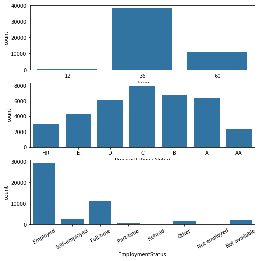

```python
fig, ax = plt.subplots(nrows=3, figsize = [8,8])
default_color = sb.color_palette()[0]
sb.countplot(data = loan_new, x = 'Term', color = default_color, ax = ax[0])
sb.countplot(data = loan_new, x = 'ProsperRating (Alpha)', color = default_color, ax = ax[1])
sb.countplot(data = loan_new, x = 'EmploymentStatus', color = default_color, ax = ax[2]);
plt.xticks(rotation=30);
```

- The length of most of the loans are 36 months.
- The ratings of most of the Prosper rating is C, followed by B and A.
- Most of borrowers are employed and full-time.

### Of the features you investigated, were there any unusual distributions? Did you perform any operations on the data to tidy, adjust, or change the form of the data? If so, why did you do this?

The distributions of stated monthly income is highly right screwed. Most stated monthly incomes are less than 30k, but some of them are incredibly high, like greater than 100k. Surprisingly, most of borrowers with greater than 100k monthly income only loan less than 5k dollars. So, the very large stated monthly income may be made up. Overall, Less than 0.3% borrowers have stated monthly income greater than 30k, these can be seemed as outlier for the following analysis, so it is better to remove borrower records with income greater than 30k.

There is no need to perform any transformations.

## Bivariate Exploration

To start off with, I want to look at the pairwise correlations present between features in the data.

```python
num_vars = ['LoanOriginalAmount', 'BorrowerAPR', 'StatedMonthlyIncome']
cat_vars = ['Term', 'ProsperRating (Alpha)', 'EmploymentStatus']
```

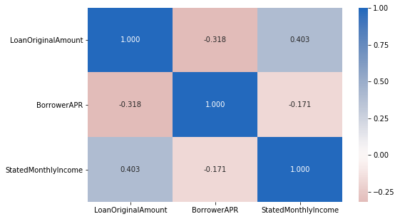

```python
# correlation plot
plt.figure(figsize = [8, 5])
sb.heatmap(loan_new[num_vars].corr(), annot = True, fmt = '.3f',
           cmap = 'vlag_r', center = 0);
```

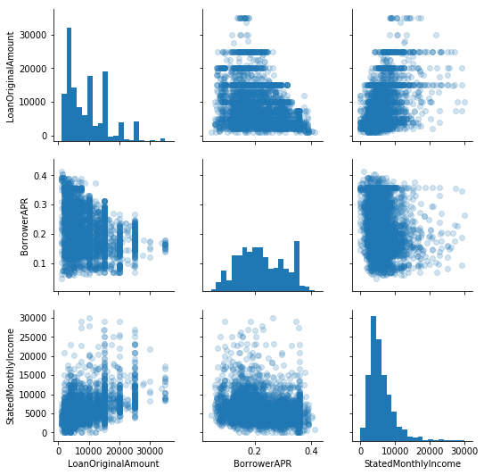

```python
# plot matrix: sample 5000 loans so that plots are clearer and render faster
loan_new_samp = loan_new.sample(5000)
g = sb.PairGrid(data = loan_new_samp.dropna(), vars = num_vars)
g = g.map_diag(plt.hist, bins=20)
g.map_offdiag(plt.scatter, alpha=0.2);
```

The correlation coefficient of borrower APR and loan original amount is -0.318, the scatter plot also shows that these two variables are negatively correlated, which agrees with our hypothesis, that is the more the loan amount, the lower the APR. The loan original amount is positively correlated with the stated monthly income, it makes sense since borrowers with more monthly income could loan more money.

Let's move on to looking at how borrower APR, stated monthly income and loan original amount correlate with the categorical variables.

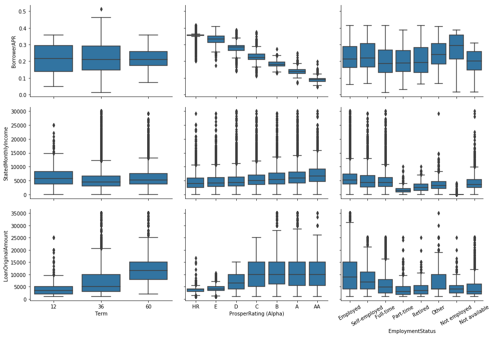

```python
# plot matrix of numeric features against categorical features.

def boxgrid(x, y, **kwargs):
    """ Quick hack for creating box plots with seaborn's PairGrid. """
    default_color = sb.color_palette()[0]
    sb.boxplot(x, y, color = default_color)

plt.figure(figsize = [10, 10])
g = sb.PairGrid(data = loan_new, y_vars = ['BorrowerAPR', 'StatedMonthlyIncome', 'LoanOriginalAmount'],
                x_vars = cat_vars, size = 3, aspect = 1.5)
g.map(boxgrid);
plt.xticks(rotation=30);
```

The figure shows that the loan amount is increased with the increase of loan term. The borrower APR decreases with the better rating. Borrowers with the best Prosper ratings have the lowest APR. It means that the Prosper rating has a strong effect on borrower APR. Borrowers with better rating also have larger monthly income and loan amount. Employed, self-employed and full time borrowers have more monthly income and loan amount than part-time, retired and not employed borrowers.

Finally, let's look at relationships between the three categorical features.

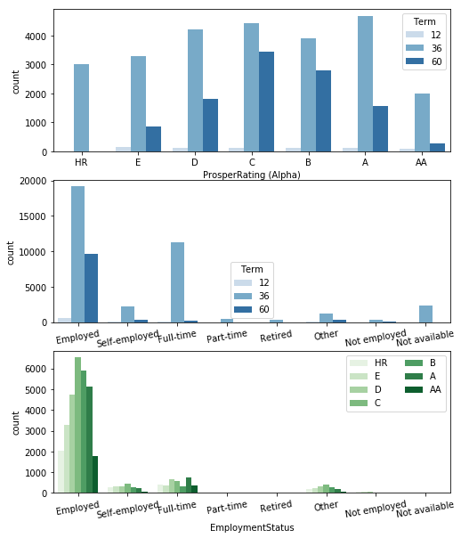

```python
plt.figure(figsize = [8, 10])

# subplot 1: Prosper rating vs term
plt.subplot(3, 1, 1)
sb.countplot(data = loan_new, x = 'ProsperRating (Alpha)', hue = 'Term', palette = 'Blues')

# subplot 2: employment status vs. term
ax = plt.subplot(3, 1, 2)
sb.countplot(data = loan_new, x = 'EmploymentStatus', hue = 'Term', palette = 'Blues')
plt.xticks(rotation=10)

# subplot 3: Prosper rating vs. employment status, use different color palette
ax = plt.subplot(3, 1, 3)
sb.countplot(data = loan_new, x = 'EmploymentStatus', hue = 'ProsperRating (Alpha)', palette = 'Greens')
ax.legend(loc = 1, ncol = 2); # re-arrange legend to remove overlapping
plt.xticks(rotation=10);
```

The employment status variable do not have enough data on part-time, retired and not employed borrowers to show its interaction with term and Prosper rating variables. But we can see that there is a interaction between term and Prosper rating. Proportionally, there are more 60 month loans on B and C ratings. There is only 36 months loans for HR rating borrowers.

With the preliminary look at bivariate relationships out of the way, I want to see how borrower APR and loan original amount are related to one another for all of the data.

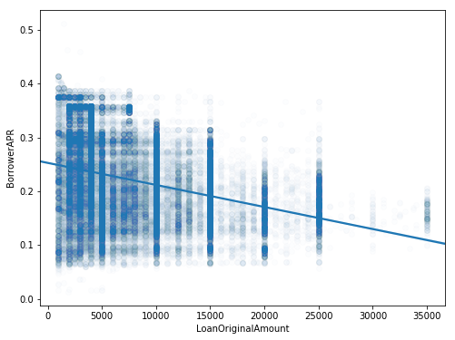

```python
plt.figure(figsize = [8, 6])
sb.regplot(data = loan_new, x = 'LoanOriginalAmount', y = 'BorrowerAPR', scatter_kws={'alpha':0.01});
```

This plot shows that at different size of the loan amount, the APR has a large range, but the range of APR decrease with the increase of loan amount. Overall, the borrower APR is negatively correlated with loan amount.

### Talk about some of the relationships you observed in this part of the investigation. How did the feature(s) of interest vary with other features in the dataset?

The borrower APR is negatively associated with the loan original amount, which mean the more the loan amount, the lower the APR. It also shows that at different size of the loan amount, the APR has a large range, but the range of APR decrease with the increase of loan amount. The Prosper rating also has a strong effect on the borrower APR, which decreases with the better rating.

### Did you observe any interesting relationships between the other features (not the main feature(s) of interest)?

The loan original amount is positively correlated with the stated monthly income, it makes sense since borrowers with more monthly income could loan more money. It also shows that borrowers with better rating also have larger monthly income and loan amount. There is a interaction between prosper rating and term. Proportionally, there are more 60 month loans on B and C ratings. There is only 36 months loans for HR rating borrowers.

## Multivariate Exploration

The main thing I want to explore in this part of the analysis is how the categorical variable (Prosper rating and term) play into the relationship between borrower APR and loan original amount.

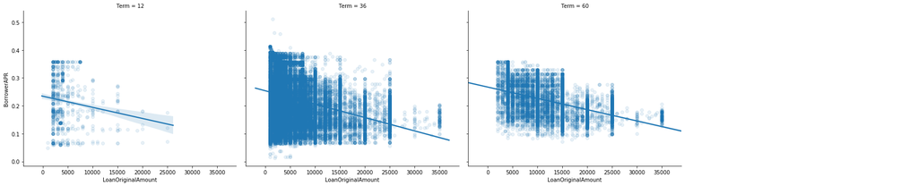

```python
# Term effect on relationship of APR and loan amount
g=sb.FacetGrid(data=loan_new, aspect=1.2, height=5, col='Term', col_wrap=4)
g.map(sb.regplot, 'LoanOriginalAmount', 'BorrowerAPR', x_jitter=0.04, scatter_kws={'alpha':0.1});
g.add_legend();
```

Term doesn't seem to have effect on relationship of APR and loan amount

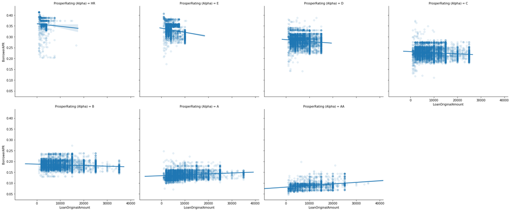

```python
# Prosper rating effect on relationship of APR and loan amount
g=sb.FacetGrid(data=loan_new, aspect=1.2, height=5, col='ProsperRating (Alpha)', col_wrap=4)
g.map(sb.regplot, 'LoanOriginalAmount', 'BorrowerAPR', x_jitter=0.04, scatter_kws={'alpha':0.1});
g.add_legend();
```

The loan amount increases with better rating. The borrower APR decreases with better rating. Interestingly, the relationship between borrower APR and loan amount turns from negative to slightly positive when the Prosper ratings are increased from HR to A or better. This may because people with A or AA ratings tend to borrow more money, increasting APR could prevent them borrow even more and maximize the profit. But people with lower ratings tend to borrow less money, decreasing APR could encourage them to borrow more.

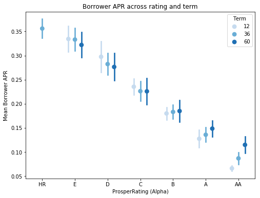

```python
ig = plt.figure(figsize = [8,6])
ax = sb.pointplot(data = loan_new, x = 'ProsperRating (Alpha)', y = 'BorrowerAPR', hue = 'Term',
           palette = 'Blues', linestyles = '', dodge = 0.4, ci='sd')
plt.title('Borrower APR across rating and term')
plt.ylabel('Mean Borrower APR')
ax.set_yticklabels([],minor = True);
```

Interestingly, the borrower APR decrease with the increase of borrow term for people with HR-C raings. But for people with B-AA ratings, the APR increase with the increase of borrow term.

Then, look at the rating and term effects on stated monthly income and loan original amount variables

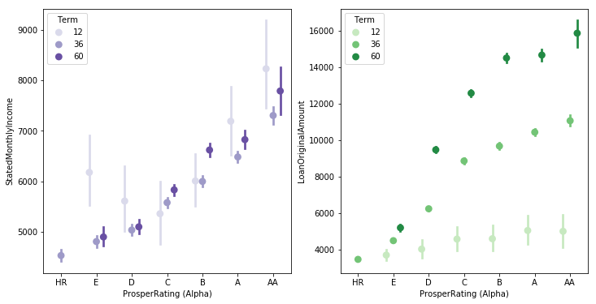

```python
fig, ax = plt.subplots(ncols=2, figsize=[12,6])
sb.pointplot(data = loan_new, x = 'ProsperRating (Alpha)', y = 'StatedMonthlyIncome', hue = 'Term',
           palette = 'Purples', linestyles = '', dodge = 0.4, ax=ax[0])
sb.pointplot(data = loan_new, x = 'ProsperRating (Alpha)', y = 'LoanOriginalAmount', hue = 'Term',
           palette = 'Greens', linestyles = '', dodge = 0.4, ax=ax[1]);
```

For stated monthly income, it doesn't seem like there is a interaction effect between term and rating, the pattern of term is similar among different ratings. But for loan amount, there is a interaction between term and rating. We can see that with better Prosper rating, the loan amount of all three terms increases, the increase amplitude of loan amount between terms also becomes larger.

### Talk about some of the relationships you observed in this part of the investigation. Were there features that strengthened each other in terms of looking at your feature(s) of interest?

I extended my investigation of borrower APR against loan amount by looking at the impact of the Prosper rating. The multivariate exploration showed that the relationship between borrower APR and loan amount turns from negative to slightly positive when the Prosper ratings increased from HR to AA. I then explored the rating and term effects on loan amount, it shows that with better Prosper rating, the loan amount of all three terms increases, the increase amplitude of loan amount between terms also becomes larger.

### Were there any interesting or surprising interactions between features?

A surprising interaction is that the borrower APR and loan amount is negatively correlated when the Prosper ratings are from HR to B, but the correlation is turned to be positive when the ratings are A and AA. Another interesting thing is that the borrower APR decrease with the increase of borrow term for people with HR-C raings. But for people with B-AA ratings, the APR increase with the borrow term.